# Lab 9: Linear Regression

# Introduction

This is Lab 9 on Data Mining. It is a simple introduction to the practicalities of linear regression.

First we load the `datamining` package and the data for the lab.

```r
library(datamining)
load('lab9.rda')
```

# The data set

The data set is 196 weeks of grocery sales for a store. The variables are:

| Variable | Description |
| --- | --- |
| Price.1 | DOLE PINEAPPLE ORANG 64 OZ |
| Price.2 | FIVE ALIVE CTRUS BEV 64 OZ |
| Price.3 | HH FRUIT PUNCH 64 OZ |
| Price.4 | HH ORANGE JUICE 64 OZ |
| Price.5 | MIN MAID O J CALCIUM 64 OZ |
| Price.6 | MIN MAID O J PLASTIC 96 OZ |
| Price.7 | MM PULP FREE OJ 64 OZ |
| Price.8 | SUNNY DELIGHT FLA CI 64 OZ |
| Price.9 | TREE FRESH O J REG 64 OZ |
| Price.10 | TROP PURE PRM HOMEST 64 OZ |
| Price.l1 | TROP SB HOMESTYLE OJ 64 OZ |
| Sold.4 | Number of units sold for HH ORANGE JUICE 64 OZ |

It is stored in a `data.frame` called `x`. We look at the first few rows of the `data.frame` using the `head` function.

```r
head(x)
```

|  | Price.1 | Price.2 | Price.3 | Price.4 | Price.5 | Price.6 | Price.7 | Price.8 | Price.9 | Price.10 | Price.11 | Sold.4 |
| --- | --- | --- | --- | --- | --- | --- | --- | --- | --- | --- | --- | --- |
| 6.5 | 2.69 | 1.99 | 0.89 | 1.89 | 1.89 | 3.89 | 2.69 | 1.36 | 2.15 | 3.13 | 2.39 | 17 |
| 7.5 | 2.69 | 1.99 | 0.89 | 1.89 | 2.37 | 3.89 | 2.37 | 1.43 | 2.15 | 3.13 | 2.39 | 60 |
| 8.5 | 2.69 | 1.99 | 0.89 | 1.89 | 1.99 | 4.19 | 1.99 | 1.43 | 2.15 | 3.05 | 2.23 | 27 |
| 9.5 | 2.69 | 1.99 | 0.89 | 1.69 | 1.99 | 4.19 | 1.99 | 1.43 | 2.15 | 2.49 | 2.23 | 382 |
| 11.5 | 2.01 | 1.99 | 0.89 | 1.49 | 2.37 | 3.99 | 2.37 | 1.45 | 2.15 | 3.05 | 2.23 | 539 |
| 15.5 | 2.69 | 1.89 | 0.89 | 1.89 | 1.79 | 3.99 | 1.79 | 1.45 | 1.79 | 3.05 | 2.19 | 204 |

# Standardising

First we make a copy of `x` and put the response in the first column of the `data.frame`. Then we transform the variable `Sold.4` so that its distribution is more evenly distributed. Next we standardise all variables to have zero mean and unit variance using the `scale` function.

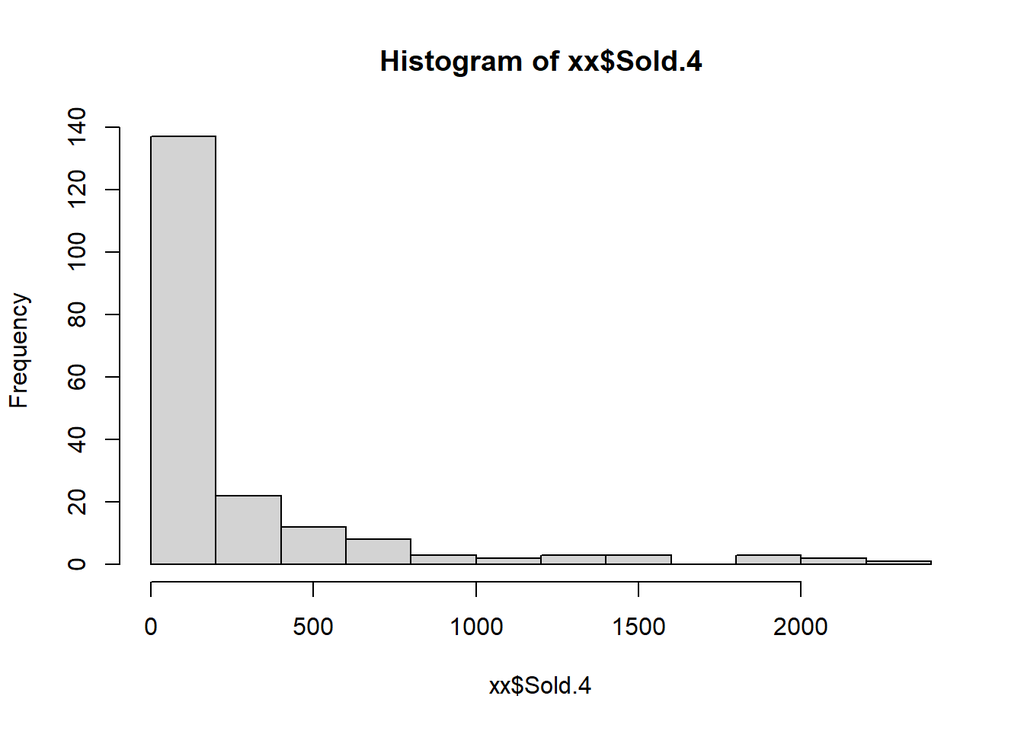

```r
xx <- x[, c(ncol(x), 1:ncol(x)-1)]
hist(xx$Sold.4)
```

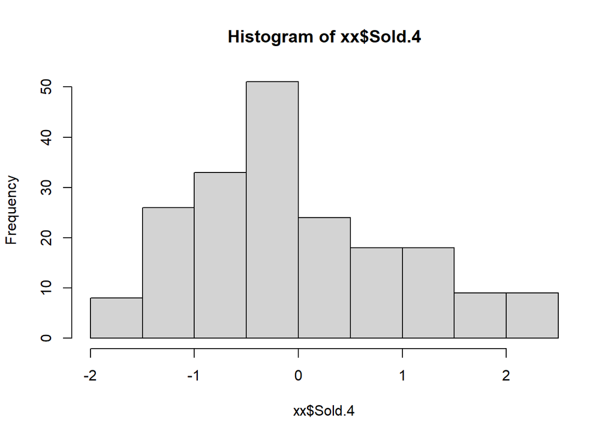

```r
xx$Sold.4 <- log(xx$Sold.4)
xx <- as.data.frame(scale(xx))
hist(xx$Sold.4)
```

# Adding predictors

Let us construct a linear model to predict `Sold.4` as a function of Price.

```r
fit <- lm(Sold.4 ~ ., data=xx)
summary(fit)
```

```
##
## Call:
## lm(formula = Sold.4 ~ ., data = xx)
##
## Residuals:
##      Min       1Q   Median       3Q      Max
## -1.64931 -0.52982 -0.06812  0.56385  1.64732
##
## Coefficients:
##               Estimate Std. Error t value Pr(>|t|)
## (Intercept)  1.320e-15  5.144e-02   0.000  1.00000
## Price.1     -6.389e-02  5.506e-02  -1.160  0.24738
## Price.2     -1.500e-03  6.880e-02  -0.022  0.98263
## Price.3      2.130e-02  5.783e-02   0.368  0.71304
## Price.4     -6.531e-01  5.761e-02 -11.337  < 2e-16 ***
## Price.5      8.692e-01  2.913e-01   2.984  0.00323 **
## Price.6     -6.336e-02  8.810e-02  -0.719  0.47298
## Price.7     -6.891e-01  2.916e-01  -2.363  0.01918 *
## Price.8     -4.441e-02  5.535e-02  -0.802  0.42344
## Price.9      1.607e-03  5.883e-02   0.027  0.97824
## Price.10     4.824e-02  6.371e-02   0.757  0.44992
## Price.11     2.911e-01  6.090e-02   4.780 3.58e-06 ***
## ---
## Signif. codes:  0 '***' 0.001 '**' 0.01 '*' 0.05 '.' 0.1 ' ' 1
##
## Residual standard error: 0.7201 on 184 degrees of freedom
## Multiple R-squared:  0.5107, Adjusted R-squared:  0.4815
## F-statistic: 17.46 on 11 and 184 DF,  p-value: < 2.2e-16
```

Then we plot all the predictors versus the residuals of this model.

```
## plotting residuals
```

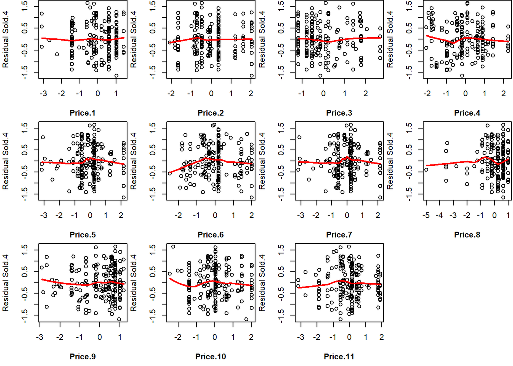

```r
predict_plot(fit, xx)
```

From the p-values, the important predictors appear to be `Price.4`, `Price.5`, `Price.7` and `Price.11`. The plots of residuals confirm that there are no anomalies in the fit.

We pick one of the important predictors from the last step and include it in a new model.

```r
fit_4 <- lm(Sold.4 ~ Price.4, data=xx)
summary(fit_4)
```

```
##
## Call:
## lm(formula = Sold.4 ~ Price.4, data = xx)
##
## Residuals:
##      Min       1Q   Median       3Q      Max
## -1.73482 -0.56929 -0.08913  0.65868  1.60808
##
## Coefficients:
##               Estimate Std. Error t value Pr(>|t|)
## (Intercept)  1.403e-16  5.643e-02    0.00        1
## Price.4     -6.157e-01  5.657e-02  -10.88   <2e-16 ***
## ---
## Signif. codes:  0 '***' 0.001 '**' 0.01 '*' 0.05 '.' 0.1 ' ' 1
##
## Residual standard error: 0.79 on 194 degrees of freedom
## Multiple R-squared:  0.3791, Adjusted R-squared:  0.3759
## F-statistic: 118.5 on 1 and 194 DF,  p-value: < 2.2e-16
```

```
## plotting residuals
```

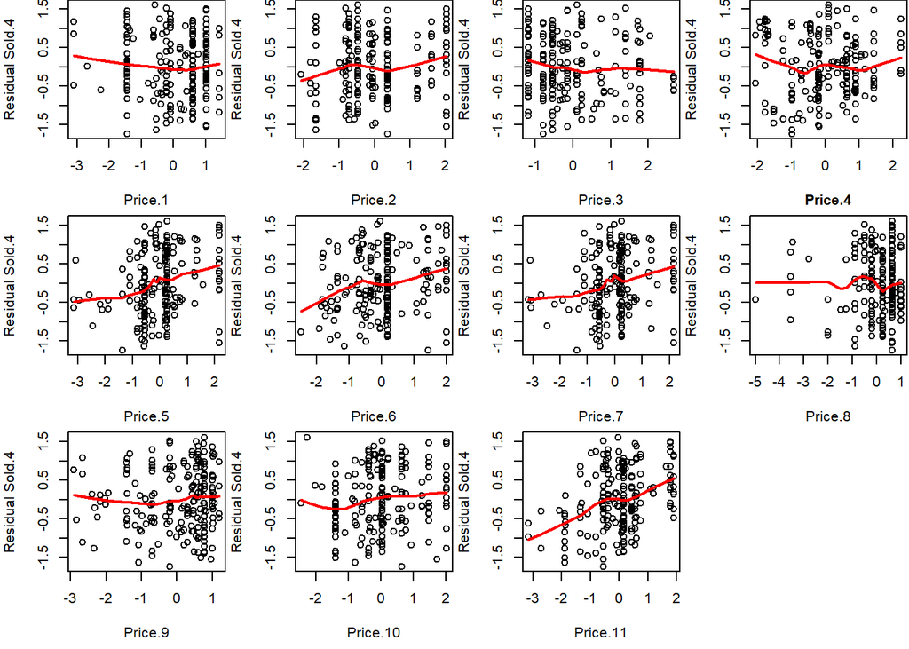

```r
predict_plot(fit_4, xx)
```

The same predictors as before seem important with `Price.11` the most important.

Next we add `Price.11` to the model.

```r
fit_4_11 <- lm(Sold.4 ~ Price.4 + Price.11, data=xx)
summary(fit_4_11)
```

```
##
## Call:
## lm(formula = Sold.4 ~ Price.4 + Price.11, data = xx)
##
## Residuals:
##     Min      1Q  Median      3Q     Max
## -1.6298 -0.5697 -0.0398  0.6173  1.6679
##
## Coefficients:
##               Estimate Std. Error t value Pr(>|t|)
## (Intercept)  2.655e-16  5.305e-02   0.000        1
## Price.4     -6.599e-01  5.388e-02 -12.249  < 2e-16 ***
## Price.11     2.772e-01  5.388e-02   5.144 6.57e-07 ***
## ---
## Signif. codes:  0 '***' 0.001 '**' 0.01 '*' 0.05 '.' 0.1 ' ' 1
##
## Residual standard error: 0.7427 on 193 degrees of freedom
## Multiple R-squared:  0.454,  Adjusted R-squared:  0.4483
## F-statistic: 80.24 on 2 and 193 DF,  p-value: < 2.2e-16
```

```
## plotting residuals
```

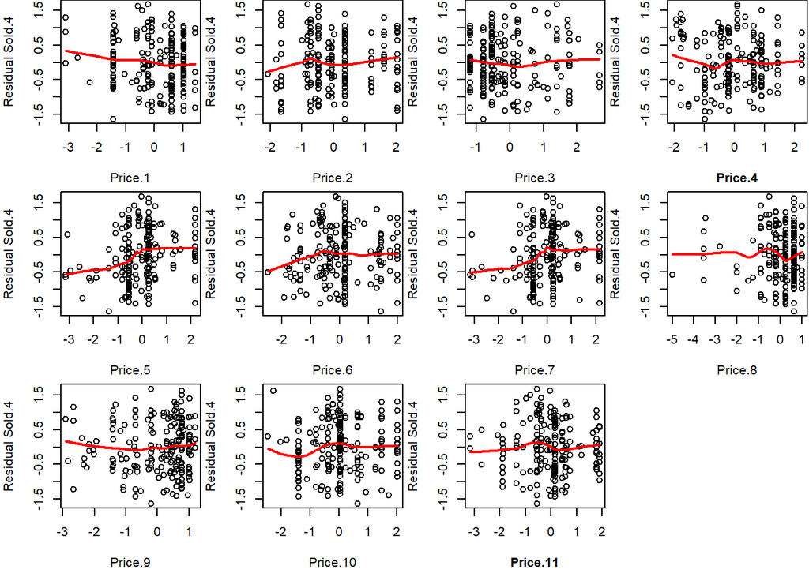

```r
predict_plot(fit_4_11, xx)
```

We keep adding predictors until no more predictors seem useful.

```r
fit_4_11_5_7 <- lm(Sold.4 ~ Price.4 + Price.11 + Price.5 + Price.7, data=xx)
summary(fit_4_11_5_7)
```

```
##
## Call:
## lm(formula = Sold.4 ~ Price.4 + Price.11 + Price.5 + Price.7,
##     data = xx)
##
## Residuals:
##      Min       1Q   Median       3Q      Max
## -1.77543 -0.45978 -0.07869  0.55778  1.66823
##
## Coefficients:
##               Estimate Std. Error t value Pr(>|t|)
## (Intercept)  1.380e-15  5.101e-02   0.000  1.00000
## Price.4     -6.782e-01  5.256e-02 -12.901  < 2e-16 ***
## Price.11     2.584e-01  5.217e-02   4.954  1.6e-06 ***
## Price.5      8.756e-01  2.820e-01   3.105  0.00219 **
## Price.7     -7.128e-01  2.825e-01  -2.523  0.01246 *
## ---
## Signif. codes:  0 '***' 0.001 '**' 0.01 '*' 0.05 '.' 0.1 ' ' 1
##
## Residual standard error: 0.7142 on 191 degrees of freedom
## Multiple R-squared:  0.5004, Adjusted R-squared:   0.49
## F-statistic: 47.83 on 4 and 191 DF,  p-value: < 2.2e-16
```

# Automatic selection

Starting again from a model with only `Price.4`, we use step to add predictors.

```r
fit_step <- step(fit_4, formula(xx))
```

```
## Start:  AIC=-90.42
## Sold.4 ~ Price.4
##
##            Df Sum of Sq    RSS      AIC
## + Price.11  1    14.599 106.47 -113.607
## + Price.5   1     8.066 113.00 -101.934
## + Price.7   1     6.094 114.98  -98.544
## + Price.6   1     4.879 116.19  -96.484
## + Price.10  1     2.691 118.38  -92.827
## <none>                  121.07  -90.422
## + Price.2   1     1.010 120.06  -90.063
## + Price.3   1     0.593 120.48  -89.384
## + Price.1   1     0.378 120.69  -89.035
## + Price.9   1     0.171 120.90  -88.699
## + Price.8   1     0.072 121.00  -88.539
## - Price.4   1    73.930 195.00    0.997
##
## Step:  AIC=-113.61
## Sold.4 ~ Price.4 + Price.11
##
##            Df Sum of Sq    RSS      AIC
## + Price.5   1     5.811 100.66 -122.607
## + Price.7   1     4.140 102.33 -119.380
## + Price.1   1     1.715 104.76 -114.791
## <none>                  106.47 -113.607
## + Price.10  1     0.904 105.57 -113.278
## + Price.6   1     0.381 106.09 -112.310
## + Price.8   1     0.170 106.30 -111.921
## + Price.2   1     0.161 106.31 -111.903
## + Price.3   1     0.012 106.46 -111.629
## + Price.9   1     0.003 106.47 -111.613
## - Price.11  1    14.599 121.07  -90.422
## - Price.4   1    82.766 189.24   -2.882
##
## Step:  AIC=-122.61
## Sold.4 ~ Price.4 + Price.11 + Price.5
##
##            Df Sum of Sq     RSS      AIC
## + Price.7   1     3.246  97.414 -127.031
## + Price.1   1     1.321  99.340 -123.195
```

[output cut: 12 more lines]

```
## Sold.4 ~ Price.4 + Price.11 + Price.5 + Price.7
##
##            Df Sum of Sq     RSS      AIC
## <none>                   97.414 -127.031
## + Price.1   1     0.871  96.543 -126.793
## + Price.8   1     0.729  96.685 -126.504
## + Price.6   1     0.445  96.970 -125.928
## + Price.10  1     0.140  97.274 -125.314
## + Price.2   1     0.104  97.310 -125.242
## + Price.9   1     0.070  97.345 -125.172
## + Price.3   1     0.030  97.385 -125.091
## - Price.7   1     3.246 100.661 -122.607
## - Price.5   1     4.917 102.332 -119.380
## - Price.11  1    12.517 109.931 -105.339
## - Price.4   1    84.891 182.305   -6.197
```

The automatically generated model is the same as that generated manually.

Finally we make a partial residual plot for the model from `step`.

```
## plotting partial residuals
```

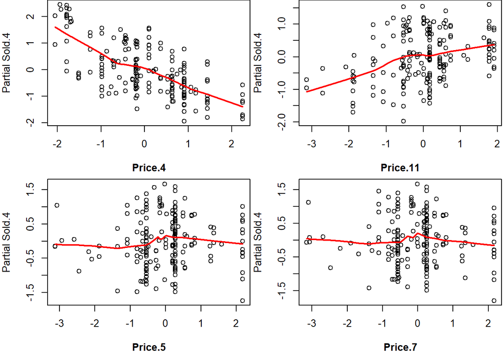

```r
predict_plot(fit_step, partial=TRUE)
```

Residual and partial residual plots are also available in the function `termplot` in the `stats` package.

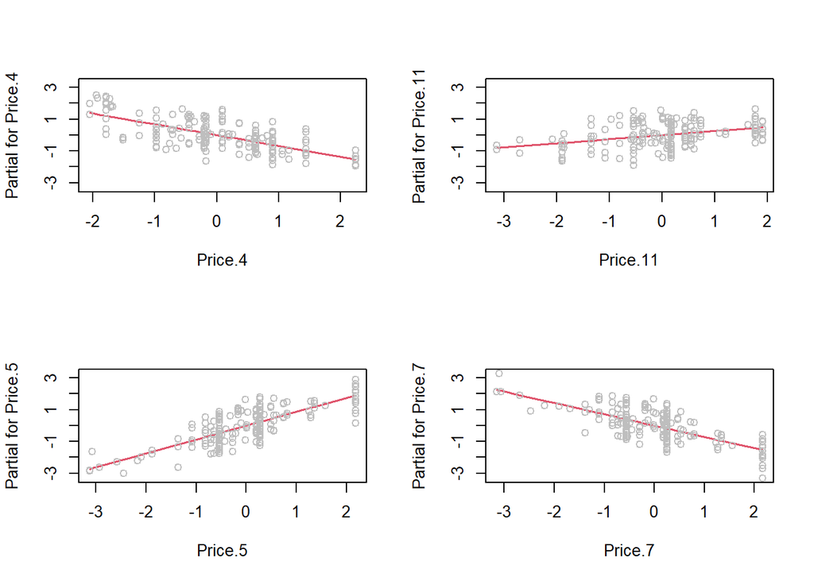

```r
library(stats)
par(mfrow = c(2, 2))
termplot(fit_step, partial.resid = TRUE, ask = FALSE)
```

```r
par(mfrow = c(1, 1))
```

Note that the partial residuals for `Sold.4` are shown using `predict_plot` whereas `termplot` uses the partial residuals for each predictor on the vertical axis.